# JSR452792 460..473

Converted from PDF `Subramony-ServiceEmployeeAttrition-2012-JSR.pdf` · 16 pages · anchors: page `#pN`, block `#pN-bK`

Page 1

See discussions, stats, and author profiles for this publication at: https://www.researchgate.net/publication/258158753

### The Long-Term Influence of Service Employee Attrition on Customer Outcomes and Profits

**Article** *in* Journal of Service Research · November 2012

DOI: 10.1177/1094670512452792

CITATIONS 63

READS 1,685

#### **2 authors:**

Mahesh Subramony

Northern Illinois University

**41** PUBLICATIONS **2,082** CITATIONS

SEE PROFILE

Brooks C. Holtom

Georgetown University

**53** PUBLICATIONS **13,598** CITATIONS

SEE PROFILE

Page 2

## http://jsr.sagepub.com/ Journal of Service Research

http://jsr.sagepub.com/content/15/4/460 The online version of this article can be found at:

DOI: 10.1177/1094670512452792

2012 15: 460 originally published online 24 July 2012 *Journal of Service Research*

#### Mahesh Subramony and Brooks C. Holtom **The Long-Term Influence of Service Employee Attrition on Customer Outcomes and Profits**

Published by:

http://www.sagepublications.com

On behalf of:

Center for Excellence in Service, University of Maryland

http://jsr.sagepub.com/cgi/alerts **Email Alerts:**

http://jsr.sagepub.com/subscriptions **Subscriptions:**

http://www.sagepub.com/journalsReprints.nav **Reprints:**

http://www.sagepub.com/journalsPermissions.nav **Permissions:**

http://jsr.sagepub.com/content/15/4/460.refs.html **Citations:**

- Jul 24, 2012 OnlineFirst Version of Record

- Oct 25, 2012 Version of Record >>

Page 3

## The Long-Term Influence of Service Employee Attrition on Customer Outcomes and Profits

#### Mahesh Subramony<sup>1</sup> and Brooks C. Holtom<sup>2</sup>

Abstract The authors proposed and tested a model linking service-employee attrition, customer-perceived service outcomes, and financial performance utilizing time-lagged data obtained from 64 business units of a temporary help services (staffing) firm. Using the notion of relational assets, the authors predicted that employee attrition (both voluntary turnover and downsizing) would disrupt the existing stock of relationships between customer-facing employees and their customers, which would have negative effects on customer outcomes and future financial performance of business units. The authors found that (a) the relationship between voluntary turnover and customer-perceived service brand image (SBI) was fully mediated by customers’ evaluations of service delivery, (b) the relationship between downsizing and SBI was fully mediated by the customer orientation levels of the unit staff, and (c) SBI significantly predicted future unit profitability. These findings point to critical factors that leaders must address when experiencing elevated levels of turnover or considering downsizing. These include focusing on developing customer orientation levels among employees through the effective use of selection, training, performance management, and compensation, minimizing employee voluntary turnover by creating positive work environments, and factoring in the long-term costs of downsizing on the organization’s SBI and future profitability.

Keywords employee turnover, service brands, customer orientation

Employee turnover has occupied the attention of scientists and practitioners for nearly a century primarily due to its proposed firm-level consequences. Yet, relatively few studies have investigated firm-level outcomes, and fewer still have examined the ‘‘black box’’ (Datta et al. 2010, p. 337) or ‘‘the mediating mechanisms between turnover and firm performance’’ (Holtom et al. 2008, p. 261). Moreover, the emergent body of turnover-related theory and research appears to have progressed along two separate streams focusing on either voluntary turnover or downsizing with limited opportunities for confluence. An integrated view, however, is warranted for three key reasons. First, emerging evidence indicates that both forms of turnover (also referred to as attrition) can exert negative effects on performance. Specifically, voluntary turnover rates have been linked to a decrease in unit-level efficiency (Morrow and McElroy 2007), customer-service outcomes (Hausknecht, Trevor, and Howard 2009), and financial performance (Glebbeek and Bax 2004). Similarly, downsizing has been found to negatively influence business outcomes including organizational efficiency (Zatzick and Iverson 2006), profitability (Guthrie and Datta 2008), and firm reputation (Flanagan and O’Shaughnessy 2005). Second, both forms of turnover are typically viewed as engendering the loss of firm-specific human and social capital (Dess and Shaw 2001)

as well as ‘‘eroding skill bases, disrupting organizational relationship networks, and . . . eliciting negative responses from survivors’’ (Datta et al. 2010, p. 322). Third, there is evidence that organizations intentionally reducing their workforces are at a greater risk of incurring further losses through employee withdrawal or quits (Spreitzer and Mishra 2002). This, in turn, suggests that the phenomena of downsizing and voluntary turnover are correlated and that the combined effects of both turnover types might be higher than either one alone.

We developed and tested an integrated model of employee attrition and its customer-related outcomes within the context of a relationship-based service business: temporary help services (THS). The THS firm recruits and manages contingent workers who provide administrative and professional services for clients, with semiautonomous regional offices (units), each

1 Department of Management, Northern Illinois University, DeKalb, IL, USA 2 McDonough School of Business, Georgetown University, Washington, DC, USA

Corresponding Author: Mahesh Subramony, Northern Illinois University, 245F Barsema Hall, DeKalb, IL 60115, USA Email: msubramony@niu.edu

Journal of Service Research 15(4) 460-473 ª The Author(s) 2012 Reprints and permission: sagepub.com/journalsPermissions.nav DOI: 10.1177/1094670512452792 http://jsr.sagepub.com

at GEORGETOWN UNIV LIBRARY on January 8, 2013 jsr.sagepub.com Downloaded from

Page 4

with its own annual objectives and performance metrics. Given that 83% of workers in the United States (Lee and Mather 2008) and approximately 60% of workers in the European Union, 27 countries (Alajaasko 2008) produce a service rather than a product and because the value of services is inextricably linked to the interaction between employees and customers (Schneider and Bowen 1985), we believe it is critical to explore the role that attrition plays in influencing valued customer outcomes. In testing our model, we also addressed one of the key design issues with existing studies in this field—the lack of a temporal focus—by utilizing time-lagged data (Holtom et al. 2008). Our key assertion is that unit-level employee turnover can result in the erosion of the firm’s customer value as reflected in its service brand image (SBI), defined as customers’ general perceptions or beliefs regarding the brand (Keller 1993). Specifically, we argue that high turnover levels reduce customer evaluation of service delivery (CESD), defined as the customer’s perception of the unit’s effectiveness in delivering core service offerings, thereby affecting SBI. We argue further that downsizing affects these valued customer outcomes through its negative influence on the unit’s collective level of customer orientation, and CESD. Finally, we propose a positive relationship between SBI and unit profitability. In the following section, we develop the theoretical rationale for our model and propose testable hypotheses.

#### Theory and Hypotheses SBI and Related Constructs: Similarities and Distinctions

Research on product and service brands typically makes a distinction between brand identity (i.e., the brand that the firm intends to communicate to the customer) and brand image (i.e., the perceptions about a brand as reflected by the brand associations held in the consumer’s memory; Keller 1993, p. 3). The latter is viewed as developing over time as a result of the accumulation of the interactions between the customer and multiple contact points such as the firm’s communication efforts and—particularly in the realm of service—the service employees (Gro¨nroos 2007). It has been argued that the creation and maintenance of a positive brand image can help service firms differentiate themselves from their competitors (Berry 2000). Specifically, when customers associate a brand with favorable attributes (e.g., trustworthiness, innovativeness, and professionalism), they are also more likely to perceive it as providing value (Brodie, Whittome, and Brush 2009) and express loyalty through repurchase (Wu, Chan, and Lau 2008) and referrals (Chaudhuri and Holbrook 2001). In addition, it has been proposed that strong brand perceptions can translate into financial brand equity (current and future cash flow), and in the long run allow the firm to extend its brand capabilities into other service categories (Burmann, Jost-Benz, and Riley 2009).

Distinctions also need to be made between SBI and CESD. Whereas CESDs are evaluations of specific service events experienced by customers, SBI represents customers’ general

perceptions or beliefs regarding the brand (Keller 1993), and is developed by customers over time as a result of both their direct experiences with service delivery (Kirmani and Zeithaml 1993) and their exposure to messages about the brand derived from other sources including marketing, advertising, and word of mouth (Romaniuk and Sharp 2003). In a qualitative analysis of interviews conducted with 20 branding experts in United Kingdom, Chernatony and Riley (1999) found that experts typically defined brand image in terms of perceptual associations in the minds of customers and as a ‘‘blending of rational and emotional components (and) that they can thrive by building a relationship with consumers, based on trust’’ (p. 186). Several researchers have attempted to measure brand image by examining the perceptual attributes associated with the brand in the minds of customers. For instance, Romaniuk and Sharp (2003) measured customer evaluations of three different brands within a B2B context on image attributes including, economical, listening, easy to work with, trustable, and solves problems. Similarly, Driesener and Romaniuk (2006) asked recent car buyers to rate various car brands on attributes such as, good value, interesting, safe, and trust using a 5-point Likert-type scale (strongly disagree to strongly agree). More recently, Chang and Liu (2009) measured customers’ brand image associations related to specific service brands in China using items such as, ‘‘Company X is socially responsible’’ and ‘‘Company X is trustworthy.’’

CESDs, on the other hand, are typically measured in terms of customer evaluations of specific service delivery facets. For instance, Giardini and Frese (2008) measured client evaluations of the service provided by financial consultants using items including, ‘‘The employee provided me with all the information I needed’’ and ‘‘The employee addressed my individual needs.’’ Similarly, Hausknecht, Trevor, and Howard (2009) used 2 items, ‘‘How friendly and helpful were the staff?’’ and ‘‘How would you rate the waiting times?’’ to measure customer evaluations of the service provided by casino staff.

In sum, the CESD and SBI constructs differ on ‘‘bandwidth’’ (i.e., the narrowness or breadth of customer cognitions). While CESD is more focused on customer evaluations of the unit, or its employees on various facets of service delivery, SBI is composed of a broader set of associations in the minds of customers regarding the firm. However, both are critical to consider in understanding and creating service brand equity (Berry 2000).

Because services are coproduced by the firm and its customers and do not exist independent of employee-customer interactions, the formation of SBI perceptions is likely to be significantly affected by the quality of firm-customer interactions (Berry 2000; de Chernatony and Segal-Horn 2001; Wentzel 2009). Thus, an investigation of SBI appears to be a natural extension of the current research linking attitudes, perceptions, and behaviors of service employees with CESD (e.g., Susskind, Kacmar, and Borchgrevink 2003). Taking the above view, we examine the effect of unit-level employee turnover on SBI, and the lagged effect of SBI on unit profitability.

Subramony and Holtom 461

at GEORGETOWN UNIV LIBRARY on January 8, 2013 jsr.sagepub.com Downloaded from

Page 5

#### Voluntary Turnover and SBI

Boundary-spanning employees (i.e., sales, customer service, and other customer-facing staff) constitute a critical link between firms and their customers (Schneider and Bowen 1985). Moreover, there is evidence that customers’ loyalty to the firm is strongly influenced by their loyalty to the firm’s representatives (Palmatier, Dant, and Grewal 2007). This is the case because repeated interactions with customers provide employees with the opportunity to develop a deeper understanding and appreciation of individual customers’ needs and preferences (Liao and Subramony 2008), and consequently lead employees to exert discretionary effort to solve customer problems (Bettencourt, Gwinner, and Meuter 2001). These discretionary behaviors are typically reciprocated by customers in the form of attachment directed specifically toward the employee (Tax and Brown 1998). Moreover, through frequent interactions over time, employees and customers often form personal bonds or relationships characterized by ‘‘vicarious experiences of each other’s behaviors, the mutual exercise of influence, and . . . the development of similar opinions, beliefs, and attitudes’’ (Dietz, Pugh, and Wiley 2004, p. 83). Because these personal relationships emerge over time and the mutual trust and commitment characterizing them are difficult to replace or replicate (Hunt 1997), the loss of customer-facing employees can significantly disrupt the delivery of service. This argument is consistent with operational disruption theory, which views employee departures as affecting ‘‘the ability of others to produce because of the interdependence of work roles’’ (Staw 1980, p. 256), thereby disrupting the normal operations of the unit and diverting unit resources (i.e., people, time, and money) toward dealing with this disruption as opposed to maintaining efficiency and high service levels (Hausknecht, Trevor, and Howard 2009).

Within THS firms, staff voluntary turnover could lead to disruption in client communication, delays in execution (e.g., filling the open position, training the new staff, etc.), additional time and effort expended on reorienting the firm’s staff, and extra emotional energy expended in rebuilding the relationship with a new partner. Moreover, units that experience higher rates of employee attrition are less likely to anticipate and deliver high-quality service (Hausknecht, Trevor, and Howard 2009) because their employees lack the critical knowledge, skills, abilities, and customer relationships found in organizational units with lower attrition rates (Kacmar et al. 2006). Thus, we expect the disruptions in service caused by voluntary turnover rates to negatively affect CESD.

Hypothesis 1. Voluntary turnover rates will negatively influ-

ence CESD.

Further, we expect CESD to affect SBI. This is because service failures and disruptions in service delivery attributed to firmrelated characteristics trigger negative perceptions and evaluations in the minds of customers (Wu, Chan, and Lau 2008) and create brand-related schemas or ‘‘clusters of interconnected

rational and irrational beliefs that are stored in memory as a unit’’ (Orth and De Marchi 2007, p. 221). For instance, frequent disruptions in service might cause customers to view the brand as being fundamentally unreliable, and inconsistencies between promised and delivered levels of service could create an impression of untrustworthiness (Lantieri and Chiagouris 2009). Interactions with employees can serve as a key source of SBI. The supplier and the customer interact with each other over time through a series of encounters and cocreate the brand relationship (Payne et al., 2009). Similarly, it has been argued that employee behaviors (if seen as typical of all employees) can be generalized to the brand itself (Wentzel 2009). In other words, SBI could become more positive or negative depending upon the service received from the employee. Thus, negative CESD is likely to lead to a negative SBI, and positive service experiences are likely to translate into a favorable SBI in the minds of customers. In other words, the effect of voluntary turnover on SBI will be indirect, that is, mediated by CESD.

Hypothesis 2. The relationship between voluntary turnover

rates and SBI will be fully mediated by CESD.

#### Downsizing and SBI

Although downsizing is typically initiated to increase efficiency levels by reducing labor costs, evidence suggests that benefits gained in terms of short-term efficiency might be offset by decreases in other relevant business outcomes including customer satisfaction, productivity, and profitability (McElroy, Morrow, and Rude 2001). This might be because downsizing initiatives can be viewed as a breach of the psychological contract (De Meuse et al. 2004) and trigger decreases in employee morale and commitment (Allen et al. 2001). We propose that, in addition, downsizing can have a detrimental effect on customer outcomes through its negative effects on both unit-level customer orientation and CESD.

Customer orientation, which is defined as a shared business unit-wide emphasis on understanding and responding to client needs and expectations (Susskind, Kacmar, and Borchgrevink 2003), can be treated as a strategic asset (Hunt 1997) that enables the firm to develop positive relationships with customers, thereby providing it with an inimitable sources of advantage over competitors (Hogan and Armstrong 2001). In other words, competitors can offer better service packages but cannot easily build the same quality or strength of relationship with customers. Indeed, recent evidence suggests that customers who perceive themselves as enjoying positive relationships with their service providers express high levels of customer satisfaction and loyalty (Palmatier et al. 2006), identify strongly with the firm (Homburg, Wieseke, and Hoyer 2009), are more tolerant of service transgressions (Gre´goire, Tripp, and Legoux 2009), and feel gratitude for its relational investments (Palmatier et al. 2009). The accumulation of these asset stocks over time is contingent upon the retention of current assets, further organizational investments, and counteraction of the forces that erode or depreciate these assets (Dierickx and

462 Journal of Service Research 15(4)

at GEORGETOWN UNIV LIBRARY on January 8, 2013 jsr.sagepub.com Downloaded from

Page 6

Cool 1989). If customer orientation is indeed a strategic asset, it can be argued that units with higher stocks ‘‘will perform better than units with lower stocks because of employees’ greater collective willingness and ability to manifest effective service behaviors’’ (Ployhart, Weekley, and Ramsey 2009, p. 1001).

Stocks of unit-level customer orientation are accumulated by hiring, socializing, developing, and rewarding customerfocused employees (Schneider, White, and Paul 1998) and could be depleted through high levels of employee downsizing. This is because, unlike voluntary turnover, downsizing is typically an organizational response to contextual factors (e.g., the economic environment, customer demands, and technology) and firm-level challenges (e.g., past performance, new strategy, and cost considerations; Datta et al. 2010), with limited consideration of employee attributes or performance (McElroy, Morrow, and Rude 2001). Moreover, downsizing has been demonstrated to have a number of deleterious effects on survivors that are not observed in response to voluntary turnover. First, the existing body of research on survivors suggests that layoffs evoke many negative attitudes among those who remain, including job insecurity and anger, which can be manifest in subsequent performance, motivation, job satisfaction (JS), and organizational commitment (Spreitzer and Mishra 2002). Second, the study of networks in organizations that have experienced downsizing reveals that survivors lost an average of five friendship ties, yet only cultivated one new friendship tie (Shah 2000). The loss of friends and the inability to generate new friendship ties decreased survivors’ social integration within the firm. This, in turn, caused disruptions of trust, work flow, and communication. Additionally, downsizing and the associated damage to a firm’s social capital may lead to the loss of knowledge stored in transitive (social system) memory and negatively impact the ability of firms to derive value from knowledge gained from employee relationships (Dess and Shaw 2001). In sum, units that downsize are more likely to see an erosion of the collective customer orientation that exists in its social network than units that do not downsize. Thus, we propose a negative relationship between downsizing and unitlevel customer orientation levels.

Hypothesis 3. Downsizing rates will negatively influence

customer orientation levels of THS staff.

In addition to the loss of human capital, downsizing can have a detrimental effect on social capital, or the knowledge embedded in social networks (Nahapiet and Ghoshal 1998). Unit-level customer orientation can be considered a shared construct emerging from the frequent interactions between unit members or as ‘‘a structure of collective action . . . that transcends the individuals who constitute the collective’’ (Morgeson and Hoffmann 1999, p. 252). We suggest that by removing multiple employees, including those bridging structural holes or spanning boundaries between different employee groups (Adler and Kwon 2002), downsizing can dissolve the social bonds among organizational members (Datta et al. 2010) and create a loss of shared purpose or agency (Leana and Van

Buren 1999). This loss of social capital is likely to be difficult to replace even with a subsequent increase in hiring due to the amount of time it takes to rebuild these social connections.

It can be further argued that customers interacting with units with low levels of customer orientation will have an unfavorable image of the service brand. As opposed to discrete or one-time exchanges common in many retail settings, interactions between THS firms and their customers occur within a longer time duration and are characterized by relational exchanges. The firm’s full-time staff and customers together identify appropriate contingent workers for various open positions, interact with each other throughout the duration of the position or project, and cycle through multiple assignments. Over the course of this relationship, THS staff and their customers develop an understanding of each other’s contexts, capabilities, and vulnerabilities and become uniquely suited to meet each others’ needs (Druker and Stanworth 2004). This mutual understanding increases the interdependence between the two parties and raises the customer’s perceived cost of switching to a different supplier (Ganesan 1994). In addition, over the long term, both parties receive opportunities to develop mutual trust and commitment (Hunt 1997) and establish mutually acceptable relational (as opposed to contractual or exchange-based) norms that ‘‘enable exchange partners to respond more effectively to environmental contingencies . . . and refrain from relationship damaging behaviors’’ (Palmatier, Dant, and Grewal 2007, p. 177). Low customer orientation levels are likely to manifest in the form of inconsistent or inadequate service delivery and a limited focus on building strong relationships with customers (Riley and de Chernatony 2000). In the context of THS firms, customer orientation may be manifest in a number of ways. For example, a THS customer’s need for temporary workers might fluctuate depending upon the business cycle (e.g., a larger sales force during holidays or more programmers during technology upgrades). Dealing with these fluctuations requires an in-depth understanding of the customer organization’s workforce skill gaps. In situations like these, a deeper understanding of customer needs and a willingness to accommodate changes in customer demands is critical, and a perceived lack of these characteristics is likely to exert a negative effect on customer perceptions of the THS employee and unit. These perceptions are, in turn, likely to influence SBI. This is because people frequently make general trait-like evaluations of individuals and groups based on their observations and interactions with these entities (Srull and Wyer 1989). Specifically, if employee behaviors are seen as typical of all employees, they are generalized to the brand itself. In other words, SBI could become more positive or negative depending upon the service received from the employee (Wentzel 2009).Thus, customers perceiving an inconsistency between employee promises and actual service delivery are likely to attribute the trait of ‘‘untrustworthiness’’ to the service brand. Because the formation of SBI is strongly influenced by employee-customer interactions (Riley and deChernatony 2000), customer-orientation levels of employees are likely to

Subramony and Holtom 463

at GEORGETOWN UNIV LIBRARY on January 8, 2013 jsr.sagepub.com Downloaded from

Page 7

influence these perceptions. Thus, customer orientation will mediate the relationship between downsizing and SBI.

Hypothesis 4. The relationship between downsizing rates

and SBI will be fully mediated by customer orientation.

In addition to proposing a mediated negative relationship between downsizing and SBI, we predict a negative relationship between downsizing and CESD. Downsizing efforts are primarily driven by a quest for efficiency and might lead to the elimination of workers possessing the skills necessary to effectively serve customers (Datta et al. 2010). Thus, it is possible that the loss of human capital and the potential disruption caused by the elimination of a part of the labor force will spillover into lower levels of service delivery. For instance, downsized units might lose staff with an understanding of particular customers’ expectations regarding specific service standards, or their unique business contexts. From the customer’s perspective, downsizing might lead to a disruption of relationships, decrease response speed (due to fewer staff performing more tasks), and increase the chances of service failure.

It should be noted that the extant literature linking downsizing with customer service outcomes is sparse. However, based on the results of a longitudinal unit-level study conducted within a financial services company (McElroy, Morrow, and Rude 2001), and recent investigations of the effects of involuntary turnover (i.e., both dismissals and discharges) on customer service performance (e.g., Batt and Colvin 2011), we propose that downsizing will negatively influence CESD.

Hypothesis 5. Downsizing rates will negatively influence

CESD.

#### SBI and Unit Profitability

There is evidence that customers who perceive a brand to have a favorable image also tend to be more loyal to it (i.e., stay with, and recommend the brand to others; Brakus, Schmitt, and Zarantonello 2009). This occurs because a favorable brand image can (a) help make the brand or firm salient in the minds of customers, thereby prompting consideration whenever they need the relevant service (Romaniuk and Sharp 2003), (b) signal product or service quality, thus reducing the uncertainty created by having to choose between multiple product/service offerings (Erdem, Swait, and Valenzuela 2008), and (c) provide functional and symbolic benefits that induce customers to reciprocate by building high levels of commitment to the brand (Wu, Chan, and Lau 2008). Thus, brand image can help differentiate the firm from its competitors and create customer loyalty (Mizik and Jacobson 2008), which in turn is linked to favorable outcomes such as revenue increases (Smith and Wright 2004). Additionally, there is evidence that customers’ positive brand perceptions can translate into their willingness to pay a premium price for the brand (Lassar, Mittal, and Sharma 1995). Finally, several studies, treating brands as strategic assets, reveal positive relationships between distinctive brand image and various measures of organizational

performance including profitability (Verbeeten and Vijn 2010), sales growth (Smith and Wright 2004), and shareholder value (Barth et al. 1998). Based on the emerging evidence from research in the realm of service branding (e.g., Brodie, Whittome, and Brush 2009), we expect to find a positive relationship between SBI and unit profitability.

Hypothesis 6. Service brand image will positively influence

future unit profitability.

464 Journal of Service Research 15(4)

at GEORGETOWN UNIV LIBRARY on January 8, 2013 jsr.sagepub.com Downloaded from

Page 8

#### Measures

Attrition. Voluntary turnover data were reported in the form of the percentage of full-time staff voluntarily leaving each unit. These rates ranged from 10% to 76%. In addition, the firm reported the percentage of full-time staff leaving each unit involuntarily (i.e., through discharges or terminations). Downsizing rates varied from 4% to 28%. Using the benchmark of 5%, which has been used previously to signal a significant and intentional workforce reduction (e.g., Guthrie and Datta 2008), we found that 86% of the units had downsized. In this study, both voluntary turnover and downsizing were treated as unitlevel continuous variables.

Customer orientation. We measured THS staff’s customerorientation levels using a scale consisting of 5 items (a ¼ .90) developed for use within the THS organization by a consulting firm. We conducted a separate study to establish the convergent validity of this scale. To do so, we administered the customer-orientation scale along with four other scales to a sample of 106 students enrolled in an undergraduate education program at a comprehensive university in the Midwest. All respondents were employed part-time with nonprofit or private service establishments in the area. We established the convergent validity of our scale by examining the correlations between respondent scores on our scale and two related measures: a 4-item External Customer Mind-Set scale (ECMS; Kennedy, Lassk, and Goolsby 2002) and a 5-item Customer Orientation scale (COS; Susskind, Kacmar, and Borchgrevink 2003). Our scale strongly correlated with both the ECMS (r ¼ .74; p ¼ .001) and the COS (r ¼ .61; p ¼ .001). Next, we established the discriminant validity of our scale by

correlating it with a 3-item measure of overall JS (Hackman and Oldham 1976) and a 5-item of affective commitment (OC; Mowday, Porter, and Steers 1982). As expected, both the JS (r ¼ .40; p ¼ .001) and the OC (r ¼ .41; p ¼ .001) scales were moderately correlated with the customer-orientation measure. Examining the statistical significance of the difference between each pair of correlations (Spector and Fox 2003) using William’s T2 formula (Steiger 1980), we found that our convergent pairs were more strongly correlated than our discriminant pairs, T(df ¼ 103) values ranging from 2.13 to 4.22; all significant at p < .05. Based on this evidence, we can conclude that the Customer-Orientation scale has adequate levels of convergent and discriminant validity.

All our analyses were conducted at the unit level (i.e., regional office). While turnover rates and the control variables were a priori conceptualized and measured at the unit level of analyses, customer-orientation data were acquired from individual respondents. Although there is ample precedent for aggregating this form of data at the unit level of analyses (e.g., Hausknecht, Trevor, and Howard 2009; Schneider, White, and Paul 1998; Susskind, Kacmar, and Borchgrevink 2003), we conducted additional analyses to ensure that employees in each regional office perceived their firm’s customer-orientation levels similarly. We did this by calculating within-group correlation (rwgj; LeBreton, James, and Lindell 2005) and the intra-class correlations (ICC1, Bliese 2000) for customer orientation. The rwgj value for customer orientation was .84, which was higher than the recommended cutoff value of .70 and statistically significant at the p < .05 level (Dunlap, Burke, and Smith-Crowe 2003). Similarly, the ICC1 values ranging from .07 to .09 indicated that between 7% and 9% of the variance in customer orientation can be attributed to between-unit differences (Bliese 2000). These results provide sufficient statistical justification for aggregation.

Table 1. Description of Survey Data

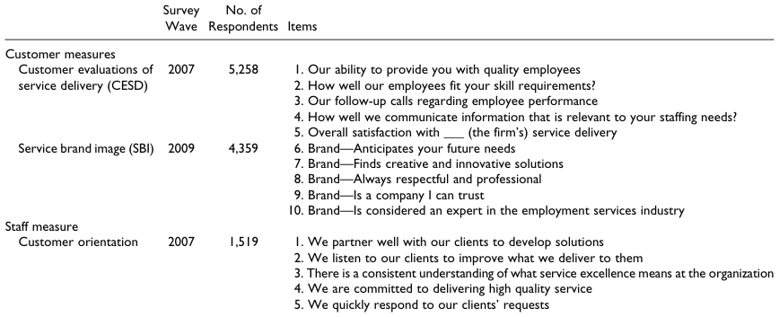

NOTE: complex table shown as an image of the PDF; the text below is a rough machine extraction and may be mis-aligned.

Subramony and Holtom 465

at GEORGETOWN UNIV LIBRARY on January 8, 2013 jsr.sagepub.com Downloaded from

Page 9

Customer measures. Both of the customer measures used in this study were designed by the THS firm’s marketing department with the support of an external market research company. CESD was measured using items specifically referring to the key aspects of service delivery within the THS context. These were rated on a 5-point scale ranging from low to high. The reliability of the CESD measure (a ¼ .86) was found to be high. SBI was measured using 5 items, each of which corresponded to a service brand attribute identified by the THS firm’s service-branding team and incorporated into the THS firm’s strategic objectives (see Appendix A). This measure also had a high level of reliability (a ¼ .92).

Our items and scales are consistent with those developed by other service researchers (e.g., Chang and Liu 2009; Driesener and Romaniuk 2006; Romaniuk and Sharp 2003). In addition to relying on past research in this area, we provided four subject matter experts a list of our survey items and requested that they categorize these items as representative of either SBI or CESD. These experts were professors of marketing with research streams related to customer service and/or branding. Two experts were on the faculty of a private university in Southeastern United States and two were on the faculty of a regional public university in the Midwest. The interrater agreement between these experts, calculated as the average level of agreement across items, was found to be high (93%) and indicated that the items in our survey were both face valid and closely aligned with literature. We also explored the discriminant validity of these constructs using confirmatory factor analysis (CFA), which is described below.

Unit profitability. Unit profit data were provided by the THS firm. Specifically, the unit profitability measure represents unit gross profits less overhead costs. Unit profits ranged from a loss of $912,647 to a profit of $3,432,286 with mean profitability of $1.32 million (SD ¼ $1.12 million).

Control variables. Based on previous evidence indicating that unit size can affect the relationship between voluntary turnover and service quality (Hausknecht, Trevor, and Howard 2009), we examined size of the regional offices (i.e., number of fulltime staff) as a possible control variable. Further, in line with previous research demonstrating the effect of regional unemployment levels on employee turnover (Trevor 2001), we examined unemployment data for the year 2005 reported for unique metropolitan regions by the Bureau of Labor Statistics (BLS; www.bls.gov).

#### Preliminary Analysis

In this study, we described CESD as a predictor of SBI. However, it is important to acknowledge two other perspectives regarding the relationship between these customer-related variables. First, might be argued that CESD and SBI are similar types of service perceptions and load on a single factor as opposed to being distinct constructs. We tested this argument by conducting a CFA where a single factor ‘‘general service

perceptions’’ model was compared with a two-factor model consisting of two distinct constructs (i.e., CESD and SBI). Further, even after establishing that CESD and SBI are distinct constructs causal ordering needs to be addressed. So, we considered reverse causality (i.e., customers’ past brand images influence their evaluations of the current service levels) as well as a reciprocal relationship between the two constructs (i.e., CESD SBI and SBI CESD). To test these alternate conceptualizations, we conducted a cross-lagged panel analysis (CLPA) using two waves of CESD and SBI data collected 4 months apart, that is, in June (Time 1) and October (Time 2) of the year 2007. Both the CFA and CLPA were conducted using data obtained from 419 customers of the THS firm.

CLPA results. The results of the CLPA analyses are presented in Figure 1. Cross-lagged models represent the effects of two or more variables on each other over time. In the current study, CLPA allows us to test the direction of the relationship between CESD and SBI. Specifically, after controlling for synchronous correlations (i.e., between CESD at Time 1 and SBI at Time 1, and CESD at Time 2 and SBI at Time 2), and autocorrelations (i.e., the effects of CESD at Times 1 and 2; and SBI at Times 1 and 2), we were able to test the cross-lagged relationship between CESD at Time 1 on SBI on Time 2, and vice versa. In our analysis, we compared a null model where the cross lags were constrained to equal zero with a model where the

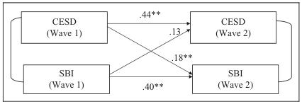

NOTE: figure/graphic rendered as an image from the PDF; its content is not machine-readable text. Caption (if any) follows as the next block.

**text found inside the figure**

.18**

.13 CESD (Wave 1)

CESD (Wave 2)

SBI (Wave 1)

SBI (Wave 2)

.44**

.40**

Figure 1. Preliminary analyses: cross-lagged panel analysis of the customer variables (N ¼ 419). Note. All path weights shown here are standardized parameter estimates. Equality constraint have been applied to covariances between customer evaluation of service delivery (CESD) and service brand image (SBI) at Time 1 (June) and Time 2 (October). *p < .05; **p < .01.

466 Journal of Service Research 15(4)

at GEORGETOWN UNIV LIBRARY on January 8, 2013 jsr.sagepub.com Downloaded from

Page 10

cross-lagged paths were unconstrained. The improvement in model fit demonstrated by the cross-lagged model, w<sup>2</sup>(1) ¼ 13.85; CFI ¼ .99; NFI ¼ .99; ECVI ¼ .10, over the baseline null model, w<sup>2</sup>(3) ¼ 41.86; CFI ¼ .96; NFI ¼ .96; ECVI ¼ .15, provided us evidence for a lagged effect of the two variables on each other, Dw<sup>2</sup>(2) ¼ 28.01; p ¼ .001; D ECVI ¼ .05. The significance of the path coefficients for the cross lags, in addition, provided us the information necessary to discern directionality. Specifically, we found that the CESD to SBI path was statistically significant (B ¼ .21; SE ¼ .08; b ¼ .18; p ¼ .007), while the path from SBI to CESD was nonsignificant (B ¼ .16; SE ¼ .08; b ¼ .13; p ¼ .06). Thus, we found support for our decision to use CESD as a predictor of SBI.

#### Results

We tested all our hypotheses using structural equations modeling implemented in AMOS 18.0 (Arbuckle 2009). In

order to ensure sufficient statistical power for our analyses, we created composite (i.e., average) scores for customer orientation, CESD, and SBI, and used these composites as manifest indicators for their corresponding latent variables. Following path analysis conventions (see Hayduk 1987), we compensated for measurement error within the manifest variables by (a) fixing their path to the latent variables to <sup>p</sup>a, where a is the reliability of each scale and (b) setting the error variance of each manifest variable to (sj

Table 2. Descriptive Statistics and Intercorrelations Between Variables in the Study

[output not shown]

NOTE: table converted from PDF layout to HTML text; cell boundaries are reconstructed. See PDF if exact alignment matters.

Note. *p .05. **p .01. Unit profitability is in million dollars.

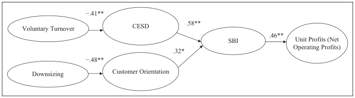

NOTE: figure/graphic rendered as an image from the PDF; its content is not machine-readable text. Caption (if any) follows as the next block.

**text found inside the figure**

CESD Voluntary Turnover

Downsizing Customer Orientation

Unit Profits (Net Operating Profits) .32*

.58**

−.48**

−.41**

.46** SBI

Figure 2. Time-lagged model of the relationship between unit-level attrition, service-related variables, and unit performance.

Subramony and Holtom 467

at GEORGETOWN UNIV LIBRARY on January 8, 2013 jsr.sagepub.com Downloaded from

Page 11

We compared our hypothesized model with three alternate models (see Table 3). First, in order to examine the importance of SBI to our overall model, we compared our hypothesized model (Model A) with Model B where the paths from customer orientation and CESD to brand image were constrained to equal zero, and the path from service image to profit was similarly constrained. We found that the hypothesized model fit our data significantly better than the alternative model, Dw<sup>2</sup>(1) ¼ 19.90; p ¼ .001. Next, we compared our hypothesized model to a ‘‘service-profit chain’’ where employee attrition influenced customer orientation; customer orientation influenced CESD, and CESD influenced profits. Once again, we found that the hypothesized model had a significantly better fit than the

alternative model, Dw<sup>2</sup>(3) ¼ 26.70; p ¼ .001. Finally, to confirm that the hypothesized model provided a parsimonious explanation of the relationship between the variables in our study, we compared it with a ‘‘full model.’’ In this model, we added paths from voluntary turnover and downsizing to both customer orientation and CESD; and direct path from customer orientation and CESD to profits; in addition to the paths in the hypothesized model. Consistent with our hypotheses, the mediation model fit our data significantly better than the full model, Dw<sup>2</sup> (1) ¼ 19.50; p ¼ .001. In sum, we find strong support for the relationships depicted in Figure 2.

#### Discussion

We proposed and tested an integrated model of unit-level attrition, customer-related outcomes, and profit within the context of a relationship-based service business. Using time-lagged data, we demonstrated the negative effect voluntary turnover has on CESD and their subsequent impact on SBI. Downsizing was shown to have a negative impact on customer orientation, which also influences SBI. We did not find a negative relationship between downsizing and CESD. Finally, we observed a strong relationship between service-brand image and profits. In short, the data confirm that high levels of attrition—whether through downsizing or voluntary turnover—have a negative impact on customers’ image of the service brand, which predict subsequent declines in unit profitability.

#### Theoretical Implications

The results of our analyses suggest that employee attrition has significant negative effects on the performance of business units. In addition, by demonstrating that CESD fully mediates the relationship between voluntary turnover and SBI and that customer orientation fully mediates the relationship between downsizing and SBI, we have taken an initial step in clarifying the contents of the ‘‘black box’’ between turnover and its performance-related consequences (Hausknecht and Trevor 2011; Holtom et al. 2008). These findings and the underlying

Table 3. Comparison of Hypothesized Model With Alternate Models

[output not shown]

NOTE: table converted from PDF layout to HTML text; cell boundaries are reconstructed. See PDF if exact alignment matters.

Note. CFI ¼ Comparative Fit Index; CESD ¼ customer evaluation of service delivery; CO ¼ customer orientation; ECVI ¼ Expected Cross-Validation Index; IFI ¼ Incremental Fit Index; PNFI ¼ Parsimony Normed Fit Index; RMSEA ¼ root mean square error of approximation.

468 Journal of Service Research 15(4)

at GEORGETOWN UNIV LIBRARY on January 8, 2013 jsr.sagepub.com Downloaded from

Page 12

theoretical mechanisms are likely to extend to contexts where customers interact with the same employee more than once, and where an understanding of a customer’s idiosyncratic needs is critical in order to provide high service levels. These contexts include many personal service settings (e.g., financial services, health care, child care) as well business-to-business relationships (e.g., industrial suppliers, professional service firms).

Additionally, as Hausknecht and Trevor (2011, p. 355) noted, ‘‘involuntary turnover dynamics are not well understood.’’ This fact coupled with the pervasiveness of reductions in force or downsizing in the United States (U.S. Department of Labor 2010) point to the importance of these empirical results. Not only is the financial impact made clear but also insights into the process by which it occurs are illuminated. Contrary to our prediction and the findings of McElroy and associates (2001), downsizing was not found to negatively influence CESD. While the reason for this finding is not completely clear, it is possible that the downsizing units in our sample were able to prevent short-term disruption to their operations by a more efficient use of their remaining employees. However, it should be noted that downsizing did have a significant negative influence on employees’ customer orientation levels, which is likely to translate into lower CESD levels in the long term.

#### Implications for Practice

The organizational behavior literature is rich with theory and associated practical recommendations for organizations desiring to reduce voluntary turnover. For many years, researchers have advocated increasing JS (Hackman and Oldham 1978) or organizational commitment (Mowday, Porter, and Steers 1982) as methods for stemming turnover. More recently, perceived organizational support (Eisenberger et al. 1986) and job embeddedness (Mitchell et al. 2001) have gained traction as theories with strong empirical support and rich recommendations for combating high levels of voluntary turnover. For example, in addition to looking at the fit an employee has with the organization, the links he or she has developed with people inside the organization and the sacrifices that would be incurred if he or she were to leave, job embeddedness looks at a person’s fit with, links in and benefits associated with the community where he or she lives (Mitchell et al. 2001). This gives the manager multiple ports for influencing employee connections to the job and surrounding area, thereby increasing the probability of staying.

Though relatively less is known about the effects of downsizing, both the decision and the process by which it occurs are controlled directly by managers. Thus, the primary practical implication of this work as it relates to downsizing is to be cognizant of its potential impact. Similar to the delay in observing the positive effect from marketing actions or service enhancements designed to improve satisfaction (van Doorn 2008), the negative effects of downsizing are most likely to be delayed. Thus, while there are obvious financial savings from planned attrition, there may be material long-term financial

implications from downsizing that managers may not predict. However, these hidden costs from downsizing and turnover may be significant and therefore important for managers to anticipate. There are a number of ways that these effects might be mitigated by addressing the mediators of the relationship with SBI directly. Specifically, the leader of a unit experiencing high rates of voluntary turnover would be well advised to reemphasize to remaining employees the importance of communicating effectively with clients to provide personalized service in order to maintain positive CESD. Similarly, knowing that downsizing affects perceptions of customer orientation, organizations that opt to downsize can try to reduce this impact by developing specific training for remaining employees that emphasizes listening to clients, partnering with them to develop effective responses in a timely manner, and ensuring that a consistent understanding of what constitutes positive service delivery exists.

Our results also highlight the importance of emphasizing customer orientation among employees. High levels of customer orientation can be obtained by selection customerfocused employees, training them in customer-related attitudes and skills, and rewarding them for customer-oriented behaviors like responsiveness, helpfulness, and relationship building (Schneider and Bowen 1995).

Further, notwithstanding evidence that time-lagged relationships reported are generally weaker than concurrent relationships, we found strong support for the mediating role of CESD in creating positive SBI and profits. Because this variable was measured using data directly from customers, we believe that the role employee continuity plays in maintaining functional relationships between the organization and its customers cannot be ignored. While the direct costs of voluntary turnover are well known (e.g., recruitment, testing, selection, training), this research adds insight into the indirect costs of attrition on profitability. In order to demonstrate the practical implications of this study, we estimated the differences in CESD and customer orientation rates for high and low attrition units as well as the profitability of units with high and low SBIs. We found that units that had high levels of voluntary turnover (i.e., at or above the 80th percentile; voluntary turnover rates at or above 42%) had an average CESD score of 3.94, while those with low voluntary turnover rates (i.e., at or below the 20th percentile; voluntary turnover rates at or below 20%) had an average CESD score of 4.19—a significant quarter scale point difference. Similarly, units that engaged in high levels of downsizing (i.e., at or above the 80th percentile; downsizing rates at or above 19%) had an average customer orientation score of 3.93, while the units with low downsizing rates (i.e., at or below the 20th percentile; downsizing rates at or below 8%) had an average customer orientation score of 4.38—a significant difference of almost a half scale point. More interestingly, units with lower levels of SBI (i.e., at or below the 20th percentile; values of 4.12 and below) had unit profits of $485,978 as compared to profits of $1,970,888 for units with higher SBI levels (i.e., at or above the 80th percentile; values of 4.34 and above). In other words, units that had

Subramony and Holtom 469

at GEORGETOWN UNIV LIBRARY on January 8, 2013 jsr.sagepub.com Downloaded from

Page 13

strong SBIs tended to be more than 4 times more profitable than units with weaker SBIs. These findings highlight the financial benefits of creating positive SBI in the minds of customers, as well as the importance of controlling employee turnover, and improving customer orientation and service delivery levels.

#### Strengths, Limitations, and Future Research Directions

One of the key strengths of this study is the use of a data set with time-lagged measures. Recently, Roe (2008) found that less than 10% of all studies published in applied psychology journals incorporated time into their theoretical framework and that fewer than 6% actually tested the temporal aspects of theorized relationships. Specific to the domain of collective turnover, 72% of studies examine it using a 1-year window. Given that proper understanding of the cause-effect timing is critical to detecting causal relationships (Mitchell and James 2001), we believe the focus on the multiyear process is critical. This study has additional methodological strengths including the control of common source variance through the use of multiple data sources and the statistical control of extraneous variables (e.g., unit size, unemployment rates) that could affect key relationships.

However, it is important to acknowledge a number of limitations as well. First among these is generalizability—a concern in any single-company study. This research was conducted in the THS setting where employees and customers interacted frequently with each other and the customer had significant input into the provision of the service—a role that has been termed coproduction by service researchers (Bendapudi and Leone 2003). In situations such as these, turnover is likely to affect CESD much more strongly than in ones where employees and customers do not interact often or where the service transaction requires only limited employee involvement (e.g., convenience-store purchases). Future studies are needed in contexts where deep bonds between employees and customers are difficult to establish or unlikely to occur.

Another limitation of this study is that we did not explore the differential effects of turnover for customers with varying expectations from the firm. It is possible that customers who require high levels of involvement with the THS firm (e.g., assistance in developing staffing plans, creating job descriptions, and serving as the primary staffing source) would be more dissatisfied with the loss of valued service providers than those who view the firm as an occasional source of contingent workers. Thus, there is a need to examine various moderators of the turnover-CESD relationship including customer expectations, level of involvement with the firm and possibly the quality of the employees who are leaving (i.e., employee performance). Another limitation of our study is that we did not investigate other forms of involuntary turnover such as performance-based discharges. In the light of recent findings linking involuntary turnover with diminishing customer service (e.g., Batt and Colvin 2011), we should expect performancebased attrition to also have a negative effect on customer outcomes. Finally, additional controls that measure important

unit-level influences (e.g., regional economic indicators, effective unit leadership) on unit profitability would also strengthen the causal claims suggested by our findings.

#### Conclusion

In sum, our study demonstrates how important continuity in staffing is to the coproduction of services by employees and customers. When turnover and downsizing rates are high, customer perceptions of SBI suffer. While the importance of employee-customer relationships has often been noted in both applied psychology and marketing literatures, our study highlights the importance of retaining customer-contact staff in order to preserve the strategic advantage available to firms through the accumulation and use of this key relational asset.

#### Appendix A Description of the SBI

1. Preamble: The attributes of our brand define our personality, our behavior, and the way we want to be seen by the outside world. It is the feeling that we want people to get when they speak to us. It is the impression they will get from our communications, our behavior, and the way we present ourselves. 2. Forward looking: We look to the future. We anticipate new developments and make sure we are ready for them. We influence many of these developments ourselves, so we are well placed to give advice on what is coming up next in the world of work. Always facing the future, always improving, we are always leading the way. 3. Expert: Working with clients and candidates every day, all over the world, we recognize how work is changing. We are knowledgeable, accurate, clear, and concise. This expertise puts us in the best position to help people understand and optimize emerging opportunities in the world of work. 4. Fresh thinking: We look at things differently, challenging the norm and finding creative, unexpected solutions. This fresh thinking leads to new and better ways of doing things. By making a wider range of different options available, we are encouraging people to think differently about work and about the choices they are making. 5. Engaging: We are warm and approachable, always finding new ways to make work more interesting. Thoughtful, respectful, and caring, we encourage people to explore new opportunities and expand their abilities. 6. Trustworthy: We are honest and truthful. We are dependable and reliable. We have integrity. People trust us to give them the facts and to help them make the right choices. When we say we will do something, we do it.

Declaration of Conflicting Interests

The author(s) declared no potential conflicts of interest with respect to the research, authorship, and/or publication of this article.

470 Journal of Service Research 15(4)

at GEORGETOWN UNIV LIBRARY on January 8, 2013 jsr.sagepub.com Downloaded from

Page 14

Funding

The author(s) received no financial support for the research, authorship, and/or publication of this article.

References

Adler, Paul S. and Seok-Woo Kwon (2002), ‘‘Social Capital:

Prospects for a New Concept,’’ Academy of Management Review, 27 (1), 17-40. Allen, Tammy D., Deena M. Freeman, Joyce E. Russell, Richard C.

Reizenstein, and Joseph O. Rentz (2001), ‘‘Survivor Reactions to Organizational Downsizing: Does Time Ease the Pain?’’ Journal of Occupational and Organizational Psychology, 74 (2), 145-164. Arbuckle, James L. 2009. Amos Version 18.0 [Computer Program].

Chicago: SPSS.Barth, Mary E., Michael B. Clement, George Foster, and Ron Kasznik (1998), ‘‘Brand Values and Capital Market Valuation,’’ Review of Accounting Studies, 3 (1/2), 41-68. Batt, Rosemary and Alexander J. Colvin (2011), ‘‘An Employment

Systems Approach to Turnover: Human Resource Practices, Quits, Dismissals, and Performance,’’ Academy of Management Journal, 54 (4), 695-717. Bendapudi, Neeli and Robert P. Leone (2003), ‘‘Psychological Impli-

cations of Customer Participation in Co-Production,’’ Journal of Marketing, 67 (1), 14-28. Berry, Leonard L. (2000), ‘‘Cultivating Service Brand Equity,’’ Jour-

nal of the Academy of Marketing Science, 28 (1), 128-137. Bettencourt, Lance A., Kevin P. Gwinner, and Matthew L. Meuter

(2001), ‘‘A Comparison of Attitude, Personality, and Knowledge Predictors of Service-Oriented Organizational Citizenship Behaviors,’’ Journal of Applied Psychology, 86 (1), 29-41. Bliese, Paul D. (2000), ‘‘Within Group Agreement, Non-Indepen-

dence, and Reliability,’’ in Multilevel Theory, Research, and Methods in Organizations, Katherine J. Klein and Steven Kozlowski, eds. San Francisco: Jossey Bass, 3-90. Brakus, J. Josko, Bernd H. Schmitt, and Lia Zarantonello (2009),

‘‘Brand Experience: What Is It? How Is It Measured? Does It Affect Loyalty?’’ Journal of Marketing, 73 (3), 52-68. Brodie, Roderick J., James R. Whittome, and Gregory J. Brush (2009),

‘‘Investigating the Service Brand: A Customer Value Perspective,’’ Journal of Business Research, 62 (3), 345-355. Burmann, Christoph, Marc Jost-Benz, and Nicola Riley (2009),

‘‘Toward an Identity-Based Brand Equity Model,’’ Journal of Business Research, 62 (3), 390-397. Chaudhuri, Arjun and Morris B. Holbrook (2001), ‘‘The Chain of

Effects from Brand Trust and Brand Affect to Brand Performance: The Role of Brand Loyalty,’’ Journal of Marketing, 65 (2), 81-93. Chang, Hsin Hsin and Ya Ming Liu (2010), ‘‘The Impact of Brand

Equity on Brand Preference and Purchase Intentions in the Service Industries,’’ Service Industries Journal, 29 (12), 1687-1706. Datta,DeepakK., James P. Guthrie,DynahBasuil, and Alankrita Pandey

(2010),‘‘CausesandEffectsofEmployeeDownsizing:AReviewand Synthesis,’’ Journal of Management, 36 (1), 281-348. De Chernatony, Leslie and Francesca Dall’Olmo Riley (1999),

‘‘Expert’s Views about Defining Services Brands and the Principles of Services Branding’’. Journal of Business Research, 46(2), 181-192.

——— and Susan Segal-Horn (2001), ‘‘Building on Services

Characteristics to Develop Successful Services Brands,’’ Journal of Marketing Management, 17 (7/8), 645-669. De, Meuse, Kenneth P., Thomas J. Bergmann, Paul A. Vanderheiden,

and Catherine E. Roraff (2004), ‘‘New Evidence Regarding Organizational Downsizing and a Firm’s Financial Performance: A Long-Term Analysis,’’ Journal of Managerial Issues, 16 (2), 155-177. Dess, Greg G. and Jason D. Shaw (2001), ‘‘Voluntary Turnover,

Social Capital, and Organizational Performance,’’ Academy of Management Review, 26 (3), 446-456. Dierickx, Ingemar and Karel Cool (1989), ‘‘Asset Stock Accumula-

tion and Sustainability of Competitive Advantage,’’ Management Science, 35 (12), 1504-1514. Dietz, Joerg, S. Douglas Pugh, and Jack W. Wiley (2004), ‘‘Service

Climate Effects on Customer Attitudes: An Examination of Boundary Conditions,’’ Academy of Management Journal, 47 (1), 81-92. Driesener, Carl and Jenni Romaniuk (2006), ‘‘Comparing Methods of

Brand Image Measurement,’’ International Journal of Market Research, 48 (6), 681-698. Druker, Janet and Celia Stanworth (2004), ‘‘Mutual Expectations: A

Study of the Three-Way Relationship between Employment Agencies, their Client Organizations and White-Collar Agency Temps,’’ Industrial Relations Journal, 35 (1), 58-75. Dunlap, William P., Michael J. Burke, and Kristin Smith-Crowe

(2003), ‘‘Accurate Tests of Statistical Significance for Rwg and Average Deviation Inter-Rater Agreement Indices,’’ Journal of Applied Psychology, 88 (2), 356-362. Eisenberger, Robert, Robin Huntington, Steven Hutchinson, and

Debora Sowa (1986), ‘‘Perceived Organizational Support,’’ Journal of Applied Psychology, 71 (3), 500-507. Erdem, Tu¨lin, Joffre Swait, and Ana Valenzuela (2006), ‘‘Brands as

Signals: A Cross-Country Validation Study,’’ Journal of Marketing, 70 (1), 34-49. Flanagan, David J. and K. C. O’Shaughnessy (2005), ‘‘The Effect of

Layoffs on Firm Reputation,’’ Journal of Management, 31 (3), 445-463. Ganesan, Shankar (1994), ‘‘Determinants of Long-Term Orientation

in Buyer-Seller Relationships,’’ Journal of Marketing, 58 (2), 1-19. Giardini, Angelo and Michael Frese (2008), ‘‘Linking Service

Employees’ Emotional Competence to Customer Satisfaction: A Multilevel Approach,’’ Journal of Organizational Behavior, 29 (2), 155-170. Glebbeek, Arie C. and Erik H. Bax (2004), ‘‘Is High Employee Turn-

over Really Harmful? An Empirical Test Using Company Records,’’ Academy of Management Journal, 47 (2), 277-286. Gre´goire, Yany, Thomas M. Tripp, and Renaud Legoux (2009),

‘‘When Customer Love Turns into Lasting Hate: The Effects of Relationship Strength and Time on Customer Revenge and Avoidance,’’ Journal of Marketing, 73 (6), 18-32. Gro¨nroos, Christian (2007), Service Management & Marketing, 3rd

ed). West Sussex, UK: John Wiley & Sons. Guthrie, James and Deepak K. Datta (2008), ‘‘Dumb and Dumber: The

Impact of Downsizing on Firm Performance as Moderated by Industry Conditions,’’ Organization Science, 19 (1), 108-123.

Subramony and Holtom 471

at GEORGETOWN UNIV LIBRARY on January 8, 2013 jsr.sagepub.com Downloaded from

Page 15

Hackman, J. Richard and Gregory R. Oldman (1976), ‘‘Motivation

through the Design of Work: Test of a Theory,’’ Organizational Behavior and Human Performance, 16 (2), 250-279. Hausknecht, John P. and Charlie O. Trevor (2011), ‘‘Collective

Turnover at the Group, Unit, and Organizational Levels: Evidence, Issues, and Implications,’’ Journal of Management, 37 (1), 352-388. ——— and Michael J. Howard (2009), ‘‘Unit-Level Voluntary Turn-

over Rates and Customer Service Quality: Implications of Group Cohesiveness, Newcomer Concentration, and Size,’’ Journal of Applied Psychology, 94 (4), 1068-1075. Hayduk, Leslie Alec (1987), Structural Equation Modeling with LIS-

REL: Essentials and Advances. Baltimore, MD: Johns Hopkins University Press. Hogan, John E. and Gary Armstrong (2001), ‘‘Toward a Resource-

Based Theory of Business Exchange Relationships: The Role of Relational Asset Value,’’ Journal of Business-to-Business Marketing, 8 (4), 3-26. Holtom, Brooks C., Terence R. Mitchell, Thomas W. Lee, and Marion

Eberly (2008), ‘‘Turnover and Retention Research: A Glance at the Past, A Closer Review of the Present, and A Venture into the Future,’’ Academy of Management Annals, 2 (1), 231-274. Homburg, Christian, Jan Wieseke, and Wayne D. Hoyer (2009),

‘‘Social Identity and the Service–Profit Chain,’’ Journal of Marketing, 73 (2), 38-54. Hunt, Shelby D. (1997), ‘‘Competing through Relationships: Ground-

ing Relationship Marketing in Resource-Advantage Theory,’’ Journal of Marketing Management, 13 (5), 431-445. Kacmar, K. Michele, Martha C. Andrews, David L. Van Rooy, R.

Chris Steilberg, and Stephen Cerrone (2006), ‘‘Sure, Everyone Can be Replaced . . . But at What Cost? Turnover as a Predictor of Unit-Level Performance,’’ Academy of Management Journal, 49 (1), 133-144. Keller, Kevin L. (1993), ‘‘Conceptualizing, Measuring, and Managing

Customer Based Brand Equity,’’ Journal of Marketing, 57 (1), 1-22. Kennedy, Karen Norman, Felicia G. Lassk, and Jerry R. Goolsby

(2002), ‘‘Customer Mind-Set of Employees throughout the Organization,’’ Journal of the Academy of Marketing Science, 30 (2), 159-171. Kirmani, Amna and Valarie Zeithaml (1993), ‘‘Advertising, Perceived

Quality and Brand Image,’’ in Brand Equity & Advertising: Advertising’s Role in Building Strong Brands, David A. Aaker and Alexander L. Biel, eds. London: Psychology Press, 143-162. Lantieri, Tara and Larry Chiagouris (2009), ‘‘Brand Trust in an Age

without Trust: Expert Opinions,’’ Journal of Consumer Marketing, 26 (2), 78-86. Lassar, Walfried, Banwari Mittal, and Arun Sharma (1995), ‘‘Measur-

ing Customer-Based Brand Equity,’’ Journal of Consumer Marketing, 12 (4), 11-19. LeBreton, James M., Lawrence R. James, and Michael K. Lindell

(2005), ‘‘Recent Issues Regarding rWG, r*WG, rWG(J), and r*WG(J),’’ Organizational Research Methods, 8 (1), 128-138. Lee, Marlene A. and Mark Mather (2008), ‘‘U.S. Labor Force

Trends,’’ Population Bulletin, 63 (2), 1-16. Leana, Carrie and Harry Van Buren (1999), ‘‘Organizational Social

Capital and Employment Practices,’’ Academy of Management Review, 24 (3), 538-555.

Liao, Hui and Mahesh Subramony (2008), ‘‘Employee Customer

Orientation in Manufacturing Organizations: Joint Influences of Customer Proximity and Senior Leadership Team,’’ Journal of Applied Psychology, 93 (2), 317-328. McElroy, James C., Paula C. Morrow, and Scott N. Rude (2001),

‘‘Turnover and Organizational Performance: A Comparative Analysis of the Effects of Voluntary, Involuntary, and Reduction-In- Force Turnover,’’ Journal of Applied Psychology, 86 (6), 1294-1299. Mitchell, Terence R. and Lawrence R. James (2001), ‘‘Building Better

Theory: Time and the Specification of when Things Happen,’’ Academy of Management Review, 26 (4), 530-547. ———, Brooks C. Holtom, Thomas W. Lee, Chris Sablynski, and

Miriam Erez (2001), ‘‘Why People Stay: Using Job Embeddedness to Predict Voluntary Turnover,’’ Academy of Management Journal, 44 (6), 1102-1121. Mizik, Natalie and Robert Jacobson (2008), ‘‘The Financial Value

Impact of Perceptual Brand Attributes,’’ Journal of Marketing Research, 45 (1), 15-32. Mooney, Christopher Z. and Robert D. Duval (1993), Bootstrapping:

A Nonparametric Approach to Statistical Inference. Newbury Park, CA: Sage Publications. Morgeson, Frederick P. and David A. Hofmann (1999), ‘‘The Struc-

ture and Function of Collective Constructs: Implications for Multilevel Research and Theory Development,’’ Academy of Management Review, 24 (2), 249-265. Morrow, Paula C. and James C. McElroy (2007), ‘‘Efficiency as a

Mediator in Turnover-Organizational Performance Relations,’’ Human Relations, 60 (6), 827-849. Mowday, Richard T., Lyman W. Porter, and Richard M. Steers (1982),

Employee-Organization Linkages: The Psychology of Commitment, Absenteeism and Turnover. San Diego, CA: Academic Press. Nahapiet, Janine and Sumantra Ghoshal (1998), ‘‘Social Capital,

Intellectual Capital, and the Organizational Advantage,’’ Academy of Management Review, 23 (2), 242-266. Orth, Ulrich R. and Renata De Marchi (2007), ‘‘Understanding the

Relations between Functional, Symbolic, and Experiential Brand Beliefs, Product Experiential Attributes, and Product Schema: Advertising-Trial Interactions Revisited,’’ Journal of Marketing Theory and Practice, 15 (3), 219-233. Palmatier, Robert W., Rajiv P. Dant, and Dhruv Grewal (2007),

‘‘A Comparative Longitudinal Analysis of Theoretical Perspectives of Interorganizational Relationship Performance,’’ Journal of Marketing, 71 (4), 172-194. ———, Cheryl Jarvis, Jennifer Bechkoff, and Frank Kardes (2009),

‘‘The Role of Customer Gratitude in Relationship Marketing,’’ Journal of Marketing, 73 (5), 1-18. ———, Rajiv P. Dant, Dhruv Grewal, and Kenneth R. Evans (2006),

‘‘Factors Influencing the Effectiveness of Relationship Marketing: A Meta-Analysis,’’ Journal of Marketing, 70 (4), 136-153. Payne, Adrain, Kaj Storbacka, Pennie Frow, and Simon Knox

(2009), ‘‘Co-Creating Brands: Diagnosing and Designing the Relationship Experience,’’ Journal of Business Research, 62 (3), 379-389. Ployhart, Robert E., Jeff Weekley, and Jase Ramsey (2009), ‘‘The

Consequences of Human Resource Stocks and Flows: A

472 Journal of Service Research 15(4)

at GEORGETOWN UNIV LIBRARY on January 8, 2013 jsr.sagepub.com Downloaded from

Page 16

Longitudinal Examination of Unit Service Orientation and Unit Effectiveness,’’ Academy of Management Journal, 52 (5), 996-1015. Riley, Francesca D. and Leslie de Chernatony (2000), ‘‘The Service

Brand as Relationships Builder,’’ British Journal of Management, 11 (2), 137-150. Roe, Robert A. (2008), ‘‘Time in Applied Psychology: The Study of

‘‘What Happens’’ Rather Than ‘‘What Is,’’ European Psychologist, 13 (1), 37-52. Romaniuk, Jenni and Byron Sharp (2003), ‘‘Brand Salience and

Customer Defection in Subscription Markets,’’ Journal of Marketing Management, 19 (1/2), 25-44. Schneider, Benjamin and David E. Bowen (1985), ‘‘Employee and

Customer Perceptions of Service in Banks: Replication and Extension,’’ Journal of Applied Psychology, 70 (3), 423-433. ———, Susan S. White, and Michelle C. Paul (1998), ‘‘Linking Ser-

vice Climate and Customer Perceptions of Service Quality: Test of a Causal Model,’’ Journal of Applied Psychology, 83 (2), 150-163. Shah, Priti P. (2000), ‘‘Network Destruction: The Structural Implica-

tions of Downsizing,’’ Academy of Management Journal, 43 (1), 101-112. Shrout, Patrick E. and Naill Bolger (2002), ‘‘Mediation in Experimen-

tal and Non-experimental Studies: New Procedures and Recommendations,’’ Psychological Methods, 7 (4), 422-445. Smith, Rodney E. and William F. Wright (2004), ‘‘Determinants of

Customer Loyalty and Financial Performance,’’ Journal of Management Accounting Research, 16, 183-205. Spector, Paul E. and Suzy Fox (2003), ‘‘Reducing Subjectivity in the

Assessment of the Job Environment: Development of the Factual Autonomy Scale (FAS),’’ Journal of Organizational Behavior, 24 (4), 417-432. Spreitzer, Gretchen M. and Anil K. Mishra (2002), ‘‘To Stay or to Go:

Voluntary Survivor Turnover Following an Organizational Downsizing,’’ Journal of Organizational Behavior, 23 (6), 707-729. Srull, Thomas K. and Robert S. Wyer (1989), ‘‘Person Memory and

Judgment,’’ Psychological Review, 96 (1), 58-83. Staw, Barry (1980), ‘‘The Consequences of Turnover,’’ Journal of

Occupational Behavior, 1 (4), 253-273. Steiger, James H. (1980),‘‘Tests for Comparing Elements of a Corre-

lation Matrix,’’ Psychological Bulletin, 87 (2), 245-251. Susskind, Alex M., K. Michelle Kacmar, and Carl P. Borchgrevink

(2003), ‘‘Customer Service Providers’ Attitudes Relating to Customer Service and Customer Satisfaction in the Customer-Server

Exchange (CSX),’’ Journal of Applied Psychology, 88 (1), 179-187. Tax, Stephen S. and Stephen W. Brown (1998), ‘‘Recovering and Learn-

ing from Service Failure,’’ Sloan Management Review, 40 (1), 75-88. Trevor, Charlie (2001), ‘‘Interactions among Actual Ease–of–Move-

ment Determinants and Job Satisfaction in Prediction of Voluntary Turnover,’’ Academy Management Journal, 44 (6), 621-638. van Doorn, (2008), ‘‘Is There a Halo Effect in Satisfaction Formation

in Business-to-Business Services?’’ Journal of Service Research, 11 (2), 124-141. Verbeeten, Frank H. M. and Pieter Vijn (2010), ‘‘Are Brand-Equity

Measures Associated with Business-Unit Financial Performance? Empirical Evidence from the Netherlands,’’ Journal of Accounting, Auditing and Finance, 25 (4), 645-671. Wentzel, Daniel (2009), ‘‘The Effect of Employee Behavior on Brand

Personality Impressions and Brand Attitudes,’’ Journal of the Academy of Marketing Science, 37 (3), 359-374. Wu, Wei-ping, T. S. Chan, and Heng Hwa Lau (2008), ‘‘Does Consu-

mers’ Personal Reciprocity Affect Future Purchase Intentions?’’ Journal of Marketing Management, 24 (3/4), 345-360. Zatzick, Christopher D. and Roderick D. Iverson (2006), ‘‘High-Com-

mitment Management and Workforce Reduction: Competitive Advantage or Disadvantage?’’ Academy of Management Journal, 49 (5), 999-1015.

Bios

Mahesh Subramony is an assistant professor of management at Northern Illinois University. His research interests are in the fields of strategic human resource management and customer service and his articles have appeared in scholarly journals including Journal of Applied Psychology, Journal of Organizational Behavior, and Human Resource Management. Dr Subramony received his PhD in Industrial/ Organizational Psychology from Central Michigan University in 1999.

Brooks C. Holtom (bch6@georgetown.edu) is an associate professor of management in the McDonough School of Business at Georgetown University. He received his BS and MAcc from Brigham Young University and his PhD in management from the University of Washington, Seattle. His research interests include the attraction, development, and retention of human and social capital.

Subramony and Holtom 473

at GEORGETOWN UNIV LIBRARY on January 8, 2013 jsr.sagepub.com Downloaded from

View publication stats